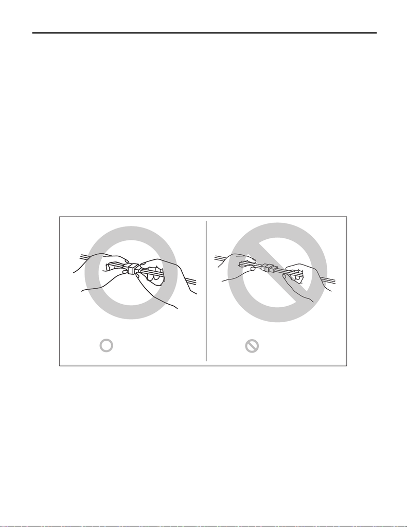

WI-18

Working Precautions

WIRING SYSTEM

2. Working Precautions

1) Always refer to “CAUTION” and “NOTE” of “General Description” in the same model’s service manual be-

fore starting the service.

2) When working under a vehicle which is jacked-up, always be sure to use rigid rack.

3) The parking brake must always be applied during working. Also, in automatic transmission vehicles, keep

the select lever set to the P (Parking) range.

4) Be sure the workshop is properly ventilated when running the engine.

5) Be careful not to touch the rotating parts such as a belt or a fan while the engine is operating.

6) Be careful not to touch hot metal parts immediately after the engine has been turned on or off.

B: PRECAUTIONS IN TROUBLE DIAGNOSIS AND REPAIR OF ELECTRIC

PARTS

1) Always refer to “CAUTION” and “NOTE” of “General Description” in the same models service manual be-

fore starting the diagnostics and repair.

2) Always refer to the cautions of each section when diagnosing and repairing each system and component.

3) The battery cable must be disconnected from the negative terminal after the ignition switch is set to the

OFF position, unless otherwise required by the diagnostics.

4) When disconnecting a connector, do not pull the harness, but pull while holding the connector housing.

5) Confirm the locking shape completely before disconnecting a connector. In addition, firmly push in the

connector until a click sounds when connecting a connector.

6) When checking continuity between connector terminals, or measuring voltage across the terminal and

ground, always touch tester probe (s) to terminals from the harness side.

If the probe is too thick to gain access to the terminal, do not push it in forcibly but use a mini test lead.

7) When measuring the voltage or resistance of individual sensor or all electrical control modules, use a ta-

pered pin with a diameter of 0.6 mm (0.024 in) or less and touch it to the tip of terminal. Never insert the ta-

pered pin into the terminal at this time. Doing so may cause internal deformation and a malfunction can occur.

WI-36088

NG

=

OK

=

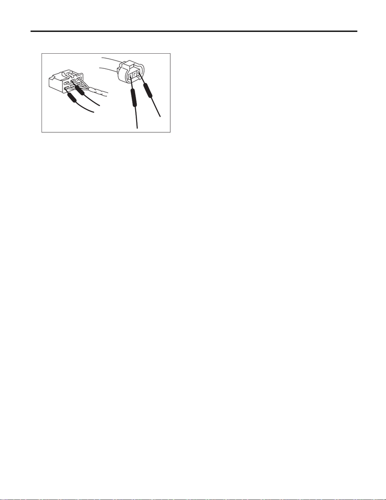

WI-19

Working Precautions

WIRING SYSTEM

8) To check water-proof connectors (which are not measurable from the harness side), touch tester probes

on the terminal side and be very careful not to bend or damage the terminals.

9) Securely fasten the harness with clamps and clips so that the harness does not interfere with the body end

parts, edges, bolts or screws.

10) When installing a harness and a component, be careful not to catch them on the harness.

11) Sensors, relays, units, etc., are sensitive to strong impacts. Handle them with extra care so that they are

not dropped or mishandled.

12) Because the HID headlight uses high voltage, be sure to confirm that the power supply is turned off be-

fore diagnostics and repair. Furthermore, do not perform diagnostics and repair with wet hands because

there is a possibility of electrical shock.

13) When inspecting the airbag system, in order to avoid malfunction, always refer to “CAUTION” of “General

Description” of the airbag system in the same model’s service manual.

WI-36089